# GWG - Bellabeat Capstone Case Study

Blake Bogdan

2022-09-01

## **Section 0: Setting the Stage**

Note: If you are here simply to see how a peer complete this case study, or to review and judge this work, skip to section 1.

Before we get to the main course of this project, there are a couple of items I want to touch on. First is providing some context as to why this analysis is being done. This project is being built as the final capstone project for the “Google Data Analytics Certification.” The course is actually 7 courses and this capstone project. Over the past month or two, I have been working through the classroom content required to obtain the certificate, which covers items like the thought processes behind a good analysis, soft skills around the analytics profession, SQL, spreadsheets, R, and so much more. Now that I have finally made my way through the course content, it is time to showcase all of that learning in this case study. There were almost unlimited options for the case study, but I chose this one because of it’s relation to fitness tracker data. I myself have thought of doing showcasing analyses using my own fitness tracking data, and when I saw that someone had already done the hard part and collected/cleaned all the data, I jumped right in.

Second up is that we need to load a couple libraries from the “tidyverse” R package in order to perform some of the coding found in this project. See the below code block for the code that was entered to load these packages:

```r
### Installs the "tidyverse" and "timetk" r packages and loads the ggplot2, tidyr, readr, and dplyr packages for use in this file.
install.packages("tidyverse")
library(ggplot2)
library(tidyr)
library(readr)
library(dplyr)
library(tidyverse)
```

With that, we’re all ready to begin. Whatever your reason for being here, thank you for taking the time to read through my work. Hopefully this project can help in any way you need, or provide an insight into my own mind and abilities. So with that, let’s begin!

## **Section 1: Introduction**

Case Study Scenario: “You are a junior data analyst working on the marketing analyst team at Bellabeat, a high-tech manufacturer of health-focused products for women. Bellabeat is a successful small company, but they have the potential to become a larger player in the global smart device market. Urška Sršen, cofounder and Chief Creative Officer of Bellabeat, believes that analyzing smart device fitness data could help unlock new growth opportunities for the company. You have been asked to focus on one of Bellabeat’s products and analyze smart device data to gain insight into how consumers are using their smart devices. The insights you discover will then help guide marketing strategy for the company. You will present your analysis to the Bellabeat executive team along with your high-level recommendations for Bellabeat’s marketing strategy.”

Click here to view the full case study

## **Section 2: Ask**

First up in the analysis cycle is to cement the business ask. Bellabeat is a growing company that is wanting to maintain their rapid growth, and the way to do that in their current stage of growth is through advertising. There are three main questions that the Bellabeat team ask in the case study documentation:

- What are the current trends in smart device use for non-Bella related devices?
- How could these trends apply to current Bella users?
- How could these trends influence future Bella marketing?

The goal of this section is to combine these splintered questions into one cohesive ask:

*Identify how Bellabeat’s target audience are using competing products, then, use these findings to more effectively market Bellabeat’s own products.*

This question will serve as the basis for the work done in each of the sections below.

## **Section 3: Prepare**

The second phase of this project, the prepare phase, has to do with planning how the business ask will be answered. For this project, there are three avenues of analysis that will be taken in order to garner insights from the fitness tracker dataset we will be using. This approach will be used in order to provide Bellabeat a variety of options for how to move forward with developing their advertising strategy.

[Click here to view the full data set on Kaggle.] (https://www.kaggle.com/datasets/arashnic/fitbit)

See each of the following three subsections for details around each of the paths to be taken.

### **Analysis Question 1: When in the day users typically burn their calories?**

#### **Question Introduction**

The first question to be addressed is to take a look at calorie burning trends for users. The goal with this analysis is to look at when in the day users burn their calories, and see if there are any discernible trends that could be used as the basis for targeted advertisements.

If the answer to this question is yes, it presents a line of advertising that could followed to appeal to a niche group of users that exist outside the majority. For example, if the trends show that there is a significant burning of calories late at night, Bellabeat could then use their advertising efforts to appeal to a user base that works out at all hours of the day. Another path Bellabeat could take could be to observe how many calories a user burns on average during times when someone would not think they are burning calories, such as while they sleep, and utilize that number to show off the calorie usage tracking capabilities of the Bellabeat product line.

#### **Data Sets to be Used**

The “hourlyCalories_merged.csv” data set will be used for this question.

```r
# Reads the "hourlyCalories_merged.csv" and assigns it to the "hourlyCalories" variable
hourlyCalories <- read_csv("hourlyCalories_merged.csv", show_col_types = FALSE)

# Displays the first few lines of the newly created "hourlyCalories" table.
head(hourlyCalories)
```

```
## # A tibble: 6 × 3
##           Id ActivityHour          Calories
##        <dbl> <chr>                    <dbl>
## 1 1503960366 4/12/2016 12:00:00 AM       81
## 2 1503960366 4/12/2016 1:00:00 AM        61
## 3 1503960366 4/12/2016 2:00:00 AM        59
## 4 1503960366 4/12/2016 3:00:00 AM        47
## 5 1503960366 4/12/2016 4:00:00 AM        48
## 6 1503960366 4/12/2016 5:00:00 AM        48
```

The “hourlyCalories” file consists of 3 fields:

- Id - ID number for which user the record belongs to. This field is being stored as a double.
- ActivityHour - The date and hour window that the calories burned count is from. This field is being stored as a character field, also known as a string.
- Calories - The amount of calories burned in the specified time frame. This field is being stored as a double.

### **Analysis Question 2: Do fitness tracker users experience a drop in weight over time?**

#### **Question Introduction**

Next up is to take a look at weight trends for users that utilize the weight log function of a fitness tracker. The goal with this analysis is to see if the utilization of the weight log function leads to positive results, meaning, are users losing weight if they are using the log?

If the answer to this question is yes, it presents a line of advertising that could appeal to the generation of results for users weight loss goals. For example, if those that use the log function do experience drops in weight over time, Bellabeat could then make the claim that users who utilize the weight log function subsequently lose weight with it’s help. The advertisement could even potentially take user data from Bellabeat’s own users and flesh out some statistics around how much the average user loses, or another statistic along that line of thought. The possibilities are numerous.

#### **Data Sets to be Used**

The “weightLogInfo_merged.csv” data set will be used for this question.

```r
# Reads the "weightLogInfo_merged.csv" and assigns it to the "weightLogInfo" variable
weightLogInfo <- read_csv("weightLogInfo_merged.csv", show_col_types = FALSE)

# Displays the first few lines of the newly created "weightLogInfo" table.
head(weightLogInfo)
```

```
## # A tibble: 6 × 8
##           Id Date                  WeightKg Weight…¹   Fat   BMI IsMan…²   LogId
##        <dbl> <chr>                    <dbl>    <dbl> <dbl> <dbl> <lgl>     <dbl>
## 1 1503960366 5/2/2016 11:59:59 PM      52.6     116.    22  22.6 TRUE    1.46e12
## 2 1503960366 5/3/2016 11:59:59 PM      52.6     116.    NA  22.6 TRUE    1.46e12
## 3 1927972279 4/13/2016 1:08:52 AM     134.      294.    NA  47.5 FALSE   1.46e12
## 4 2873212765 4/21/2016 11:59:59 PM     56.7     125.    NA  21.5 TRUE    1.46e12
## 5 2873212765 5/12/2016 11:59:59 PM     57.3     126.    NA  21.7 TRUE    1.46e12
## 6 4319703577 4/17/2016 11:59:59 PM     72.4     160.    25  27.5 TRUE    1.46e12
## # … with abbreviated variable names ¹WeightPounds, ²IsManualReport
```

The “weightLogInfo_merged.csv” file consists of the following fields:

- Id - ID number for which user the record belongs to. This field is being stored as a double.
- Date - The date the log entry is from, and the time it was entered. This field is being stored as a character field, also known as a string.
- WeightKG - The weight of the user on the given day, represented in killograms. This field is being stored as a double.
- WeightPounds - The weight of the user on the given day, represented in pounds. This field is being stored as a double.
- Fat - With no metadata for the dataset, the meaning of this field is not know. It will be cut from the final analysis in the cleaning phase.
- BMI - The calculated BMI of the user for the given day. This field is being stored as a double.
- IsManualReport - An indication on whether the log for this day was manually entered, or was automatic. This field is being stored as an LGL.
- LogID - A unique ID for the specific log entry. Used to discern between log entries from the same day. This field is being stored as a double.

#### **Planned Visualizations**

The visualization to be used in this scenario is scatterplot, plotting a weight log entry against the date it was entered.

### **Analysis Question 3: How does a user’s resting heart rate vary, based on the amount of total time they spend in each of the activity levels?**

#### **Question Introduction**

The final areas of analysis involves the exercise data of a user. Specifically, does the amount of time a user spends in each of the specified activity levels correlate at all to the user’s resting heart rate?

The advertising potential for the answer to this question is similar to that of question two, in that it is result related. For example, if the answer to this question is that those that spend more time being active experience a lower resting heart rate, then Bellabeat could claim that those that keep track of their activity level using Bellabeat products experience a healthier heart. Again, this analysis could form the basis for further research, and Bellabeat could then utilize statistics from their own user base to support their claim. For example, generating statistics around how much lower a user’s heart rate tends to be, based on various levels of activity.

#### **Data Sets to be Used**

The “heartrate_seconds_merged.csv” and the “minuteIntensitiesNarrow_merged.csv” data sets will be used for this question.

```r
# Reads the "heartrate_seconds_merged.csv" and assigns it to the "heartrate_seconds" variable
heartrate_seconds <- read_csv("heartrate_seconds_merged.csv", show_col_types = FALSE)

# Displays the first few lines of the newly created "heartrate_seconds" table.
head(heartrate_seconds)
```

```
## # A tibble: 6 × 3
##           Id Time                 Value
##        <dbl> <chr>                <dbl>
## 1 2022484408 4/12/2016 7:21:00 AM    97
## 2 2022484408 4/12/2016 7:21:05 AM   102
## 3 2022484408 4/12/2016 7:21:10 AM   105
## 4 2022484408 4/12/2016 7:21:20 AM   103
## 5 2022484408 4/12/2016 7:21:25 AM   101
## 6 2022484408 4/12/2016 7:22:05 AM    95
```

The “heartrate_seconds_merged.csv” file consists of the following fields:

- Id - ID number for which user the record belongs to. This field is being stored as a double.
- Time - The date, hour, minute, and second that the heart rate reading is from. This field is being stored as a character field, also known as a string.
- Value - The users heart rate at the specified time. This field is being stored as a double.

```r
# Reads the "minuteIntensitiesNarrow_merged.csv" and assigns it to the "minuteIntensities" variable
minuteIntensities <- read_csv("minuteIntensitiesNarrow_merged.csv", show_col_types = FALSE)

# Displays the first few lines of the newly created "minuteIntensities" table.
head(minuteIntensities)
```

```
## # A tibble: 6 × 3
##           Id ActivityMinute        Intensity
##        <dbl> <chr>                     <dbl>
## 1 1503960366 4/12/2016 12:00:00 AM         0
## 2 1503960366 4/12/2016 12:01:00 AM         0
## 3 1503960366 4/12/2016 12:02:00 AM         0
## 4 1503960366 4/12/2016 12:03:00 AM         0
## 5 1503960366 4/12/2016 12:04:00 AM         0
## 6 1503960366 4/12/2016 12:05:00 AM         0
```

In order to connect the two data sets, a join will have to be done on each sets “ID” field.

## **Section 4: Process**

The third phase of this project is the data cleaning process. Each subsection will detail the data cleaning steps taken, broken down per individual file mentioned in the previous section. There is good news about the data to be used; the source of the data has already cleaned the data. However, there is one change to be made, and that is to convert some of the date/time columns from a string into a specific date/time format.

### **Question 1: “hourlyCalories” Data Set**

See the below code chunk for details on each step taken in the data cleaning and transformation process. Each step (represented by each line of code) is detailed and explained by the comment above it:

```r
# Reclasses the "ActivityHour" column into a date/time format, so as to convert the time to a 24-hour clock format
hourlyCalories$ActivityHour = as.POSIXct(hourlyCalories$ActivityHour, format="%m/%d/%Y %I:%M:%S %p", tz=Sys.timezone())

# Separates the ActivityHour column into separate columns, one for the date and one for the time
hourlyCalories <- separate(hourlyCalories, ActivityHour, into = c("ActivityDate", "ActivityHour"), sep = " ")

# Takes the cleaned hourlyCalories dataset, groups the data by the ActivityHour, and then calculates the average amount of calories burned per hour of the day
groupedHourlyCalories <- hourlyCalories %>%
  group_by(ActivityHour) %>%
  summarise(TotalCalories = mean(Calories))

# Removes the unused minute and second fields from the "ActivityHour" column
groupedHourlyCalories$ActivityHour <- substr(groupedHourlyCalories$ActivityHour, 1, 2)

# Displays the first few lines of the newly created "groupedHourlyCalories" table.
head(groupedHourlyCalories)
```

```
## # A tibble: 6 × 2
##   ActivityHour TotalCalories
##   <chr>                <dbl>
## 1 00                    71.8
## 2 01                    70.2
## 3 02                    69.2
## 4 03                    67.5
## 5 04                    68.3
## 6 05                    81.7
```

Now that the data is cleaned, transformed, and ready to be visualized, it is time to move on to building the actual visualization:

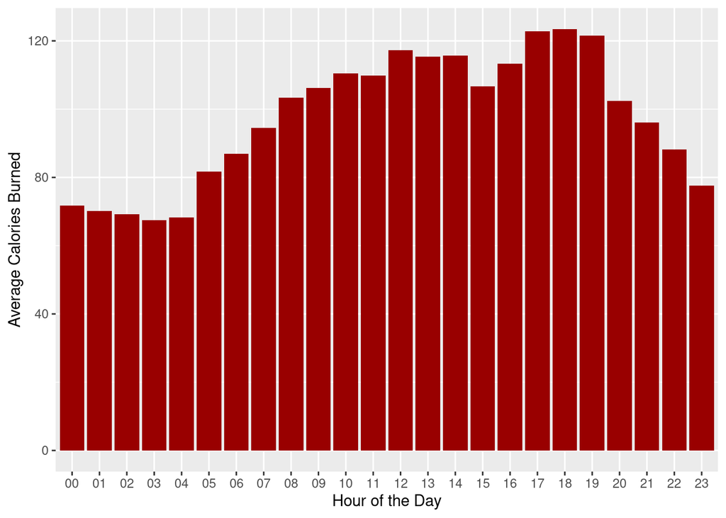

```r
# Creates a bar chart based on the "groupedHourlyCalories" table, and assigns it to the "visualHourlyCaloriesBurned" variable.
visualHourlyCaloriesBurned <- ggplot(data = groupedHourlyCalories, aes(x = ActivityHour, y = TotalCalories)) +
  geom_bar(stat = "identity", fill = "#990000") +
  xlab("Hour of the Day") +
  ylab("Average Calories Burned")

# Displays the created "visualHourlyCaloriesBurned" chart.
visualHourlyCaloriesBurned
```

### **Question 2: weightLogInfo**

See the below code chunk for details on each step taken in the data cleaning and transformation process. Each step (represented by each line of code) is detailed and explained by the comment above it:

```r
# Takes the "Time" column and reclasses it to a date/time format
weightLogInfo$Date = as.POSIXct(weightLogInfo$Date, format="%m/%d/%Y %I:%M:%S %p", tz=Sys.timezone())

# Separates the "Time" column into the data and time aspects.
weightLogInfo <- separate(weightLogInfo, Date, into = c("ActivityDate", "ActivityTime"), sep = " ")

# Reclases the "ActivityDate" column to a date time format
weightLogInfo$ActivityDate = as.POSIXct(weightLogInfo$ActivityDate)

# Displays the first few lines of the newly created "weightLogInfo" table.
head(weightLogInfo)
```

```
## # A tibble: 6 × 9
##       Id ActivityDate        Activ…¹ Weigh…² Weigh…³   Fat   BMI IsMan…⁴   LogId
##    <dbl> <dttm>              <chr>     <dbl>   <dbl> <dbl> <dbl> <lgl>     <dbl>
## 1 1.50e9 2016-05-02 00:00:00 23:59:…    52.6    116.    22  22.6 TRUE    1.46e12
## 2 1.50e9 2016-05-03 00:00:00 23:59:…    52.6    116.    NA  22.6 TRUE    1.46e12
## 3 1.93e9 2016-04-13 00:00:00 01:08:…   134.     294.    NA  47.5 FALSE   1.46e12
## 4 2.87e9 2016-04-21 00:00:00 23:59:…    56.7    125.    NA  21.5 TRUE    1.46e12
## 5 2.87e9 2016-05-12 00:00:00 23:59:…    57.3    126.    NA  21.7 TRUE    1.46e12
## 6 4.32e9 2016-04-17 00:00:00 23:59:…    72.4    160.    25  27.5 TRUE    1.46e12
## # … with abbreviated variable names ¹ActivityTime, ²WeightKg, ³WeightPounds,
## #   ⁴IsManualReport
```

Now that the data is cleaned, transformed, and ready to be visualized, it is time to move on to building the actual visualization:

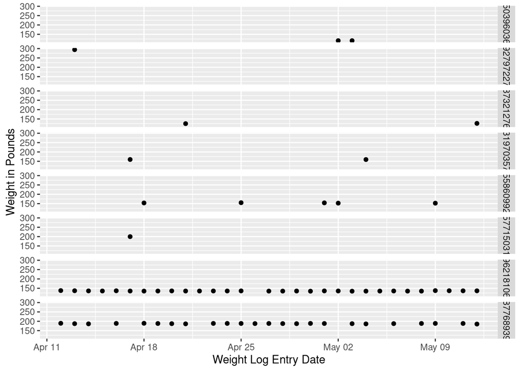

```r
# Plots the data set into multiple scatterplots, each plot representing a different user. The "ActivityDate" column is on the X axis, and the user's weight ("WeightPounds") is on the Y axis.
ggplot(data = weightLogInfo, aes(x = ActivityDate, y = WeightPounds)) +
  geom_point(stat = "identity") +
  facet_grid(rows = vars(Id)) +
  xlab("Weight Log Entry Date") +
  ylab("Weight in Pounds")
```

Taking a first look at the visual, it is clear that some of the users that had weight log info only used the function sparingly. Therefore, their data points only serve to be mixed in and muddy the analysis, as they cannot show the trend in the user’s weight over time. Therefore, the three users with consistent to semi-consistent weight log entries will only be used for this activity. The following code chunk filters the existing table that was created earlier to those three users, and subsequently builds the visualization using the filtered data:

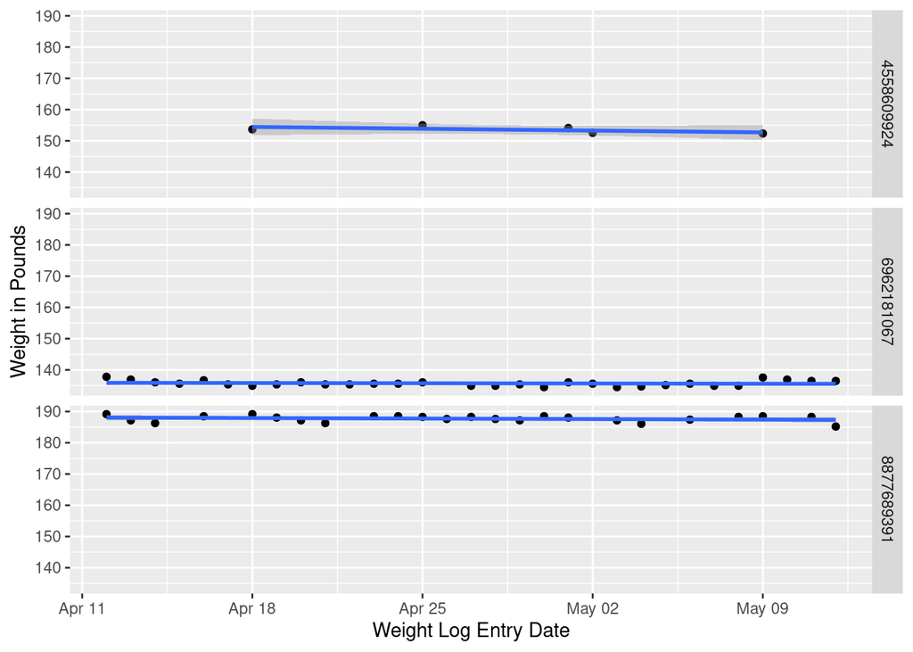

```r
#Filters the weight log info to only the three users with consistent log entries, and stores it in a new table titled "weightLogInfoFiltered."
weightLogInfoFiltered <- filter(weightLogInfo, Id == 6962181067 | Id == 8877689391 | Id == 4558609924)

# Plots the new table in a scatterplot, with the "ActivityDate" on the X axis, and the "WeightPounds" on the Y axis. Created 3 visuals, each one representing the weight logs from the three users filtered for in the previous step.
visualWeightLogEntries <- ggplot(data = weightLogInfoFiltered, aes(x = ActivityDate, y = WeightPounds)) +
  facet_grid(vars(Id)) +
  geom_point(stat = "identity") +
  geom_smooth(method=lm) +
  xlab("Weight Log Entry Date") +
  ylab("Weight in Pounds")

# Displays the created weight log visual
visualWeightLogEntries
```

### **Question 3: heartrate_seconds and minuteIntensities**

See the below code chunk for details on each step taken in the data cleaning and transformation process. Each step (represented by each line of code) is detailed and explained by the comment above it. This first chunk will represent the described process for the “heartrate_seconds” table:

```r
# Takes the "Time" column and reclasses it to a date/time format
heartrate_seconds$Time = as.POSIXct(heartrate_seconds$Time, format="%m/%d/%Y %I:%M:%S %p", tz=Sys.timezone())

# Groups the hearrate_seconds table by the "Id" field (user ID) and finds the minimum recorded heartrate for each user. It then assigns this result to the minHeartRates variable.
minHeartRates <- heartrate_seconds %>%
  group_by(Id) %>%
  summarise(MinHeartRate = min(Value))

# Displays the first few lines of the newly created "minHeartRates" table.
head(minHeartRates)
```

```
## # A tibble: 6 × 2
##           Id MinHeartRate
##        <dbl>        <dbl>
## 1 2022484408           38
## 2 2026352035           63
## 3 2347167796           49
## 4 4020332650           46
## 5 4388161847           39
## 6 4558609924           44
```

See the below code chunk for details on each step taken in the data cleaning and transformation process. Each step (represented by each line of code) is detailed and explained by the comment above it. This second chunk will represent the described process for the “minuteIntensities” table:

```r
# Takes the "Time" column and reclasses it to a date/time format.
minuteIntensities$ActivityMinute = as.POSIXct(minuteIntensities$ActivityMinute, format="%m/%d/%Y %I:%M:%S %p", tz=Sys.timezone())

# Groups the minuteIntensities table by the "Id" field (user ID), filters to only include minutes spent at activity level 0, and then counts the total number of minutes the user spent at activity level 0. It then assigns the resulting table to the "ActivityMinutes0" variable.
ActivityMinutes0 <- minuteIntensities %>%
  group_by(Id) %>%
  filter(Intensity == 0) %>%
  summarise(TotalAtLevel0 = n())

# Groups the minuteIntensities table by the "Id" field (user ID), filters to only include minutes spent at activity level 1, and then counts the total number of minutes the user spent at activity level 1. It then assigns the resulting table to the "ActivityMinutes1" variable.
ActivityMinutes1 <- minuteIntensities %>%
  group_by(Id) %>%
  filter(Intensity == 1) %>%
  summarise(TotalAtLevel1 = n())

# Groups the minuteIntensities table by the "Id" field (user ID), filters to only include minutes spent at activity level 2, and then counts the total number of minutes the user spent at activity level 2. It then assigns the resulting table to the "ActivityMinutes2" variable.
ActivityMinutes2 <- minuteIntensities %>%
  group_by(Id) %>%
  filter(Intensity == 2) %>%
  summarise(TotalAtLevel2 = n())

# Groups the minuteIntensities table by the "Id" field (user ID), filters to only include minutes spent at activity level 3, and then counts the total number of minutes the user spent at activity level 3. It then assigns the resulting table to the "ActivityMinutes3" variable.
ActivityMinutes3 <- minuteIntensities %>%
  group_by(Id) %>%
  filter(Intensity == 3) %>%
  summarise(TotalAtLevel3 = n())

# The following three lines merges the 4 tables previously created in this chunk and assigns it to the new table "mergedActivityMinutes."
mergedActivityMinutes <- merge(ActivityMinutes0, ActivityMinutes1, by = "Id")
mergedActivityMinutes <- merge(mergedActivityMinutes, ActivityMinutes2, by = "Id")
mergedActivityMinutes <- merge(mergedActivityMinutes, ActivityMinutes3, by = "Id")

# Displays the first few lines of the newly created "mergedActivityMinutes" table.
head(mergedActivityMinutes)
```

```
##           Id TotalAtLevel0 TotalAtLevel1 TotalAtLevel2 TotalAtLevel3
## 1 1503960366         34420          6806           594          1200
## 2 1624580081         38961          4750           180           269
## 3 1644430081         36245          5307           643           285
## 4 1844505072         40237          3579            40             4
## 5 1927972279         42899          1196            24            41
## 6 2022484408         34442          7933           600          1125
```

Now that each of the two tables are built out, it is time to merge them into one complete table and then create the visualization:

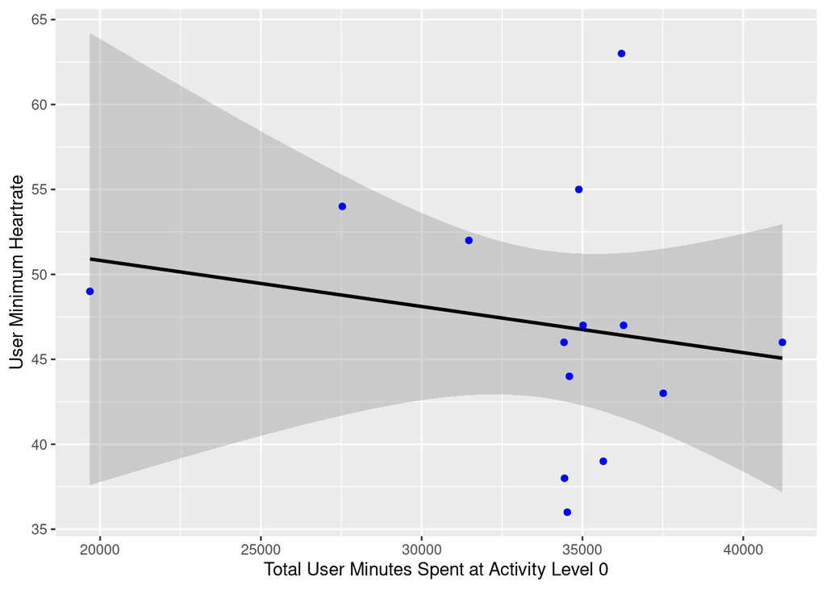

```r
# Creates the mergedIntensitiesHeartRate data set by merging the mergedActivityMinutes (total minutes spent at each activity level by user) and the minHeartRates (minimum heartrate of each user) on the variable "Id" (user ID)
mergedIntensitiesMinHeartRate <- merge(mergedActivityMinutes, minHeartRates, by = "Id")

# Creates a scatterplot charting the total number of minutes a user spent at activity level 3, versus their minimum heartrate. Assigns it to the variable minHeartRate_vs_Level0. Points are specified to be blue to improve differentiation from sister charts.
visualminHeartRate_vs_Level0 <- ggplot(mergedIntensitiesMinHeartRate, aes(x = TotalAtLevel0, y = MinHeartRate)) +
  geom_smooth(method=lm, color = "black") +
  geom_point(stat = "identity", color = "#0000FF") +
  xlab("Total User Minutes Spent at Activity Level 0") +
  ylab("User Minimum Heartrate")

# Creates a scatterplot charting the total number of minutes a user spent at activity level 3, versus their minimum heartrate. Assigns it to the variable minHeartRate_vs_Level1. Points are specified to be yellow to improve differentiation from sister charts.
visualminHeartRate_vs_Level1 <- ggplot(mergedIntensitiesMinHeartRate, aes(x = TotalAtLevel1, y = MinHeartRate)) +
  geom_smooth(method=lm, color = "black") +
  geom_point(stat = "identity", color = "#FFCC00") +
  xlab("Total User Minutes Spent at Activity Level 1") +
  ylab("User Minimum Heartrate")

# Creates a scatterplot charting the total number of minutes a user spent at activity level 3, versus their minimum heartrate. Assigns it to the variable minHeartRate_vs_Level2. Points are specified to be red to improve differentiation from sister charts.
visualminHeartRate_vs_Level2 <- ggplot(mergedIntensitiesMinHeartRate, aes(x = TotalAtLevel2, y = MinHeartRate)) +
  geom_smooth(method=lm, color = "black") +
  geom_point(stat = "identity", color = "#FF9966") +
  xlab("Total User Minutes Spent at Activity Level 2") +
  ylab("User Minimum Heartrate")

# Creates a scatterplot charting the total number of minutes a user spent at activity level 3, versus their minimum heartrate. Assigns it to the variable minHeartRate_vs_Level3. Points are specified to be red to improve differentiation from sister charts.
visualminHeartRate_vs_Level3 <- ggplot(mergedIntensitiesMinHeartRate, aes(x = TotalAtLevel3, y = MinHeartRate)) +
  geom_smooth(method=lm, color = "black") +
  geom_point(stat = "identity", color = "#990000") +
  xlab("Total User Minutes Spent at Activity Level 3") +
  ylab("User Minimum Heartrate")

# Displays each of the created charts.
visualminHeartRate_vs_Level0
```

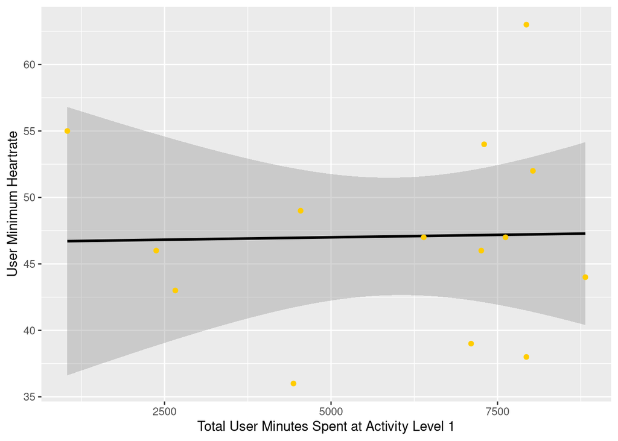

```r
visualminHeartRate_vs_Level1
```

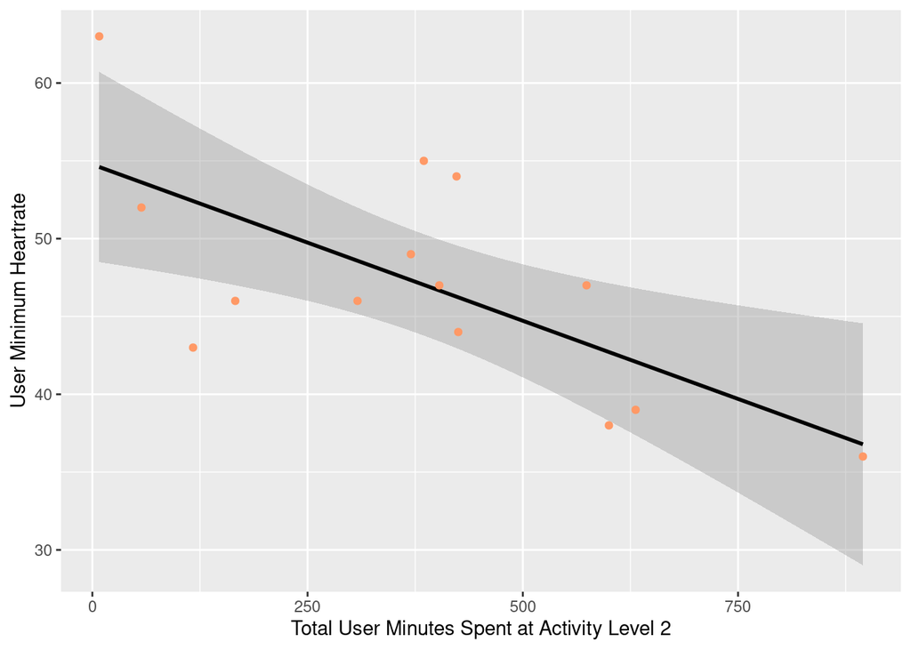

```r
visualminHeartRate_vs_Level2
```

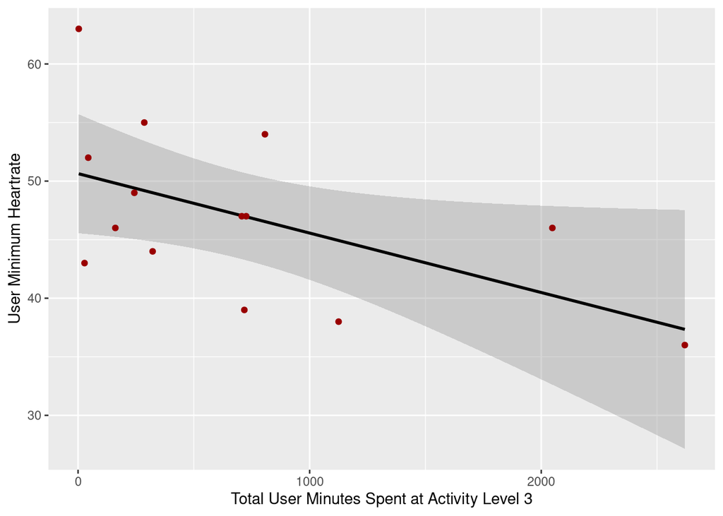

```r
visualminHeartRate_vs_Level3
```

## **Section 5: Analyze**

### **Analysis Question 1: When in the day users typically burn their calories?**

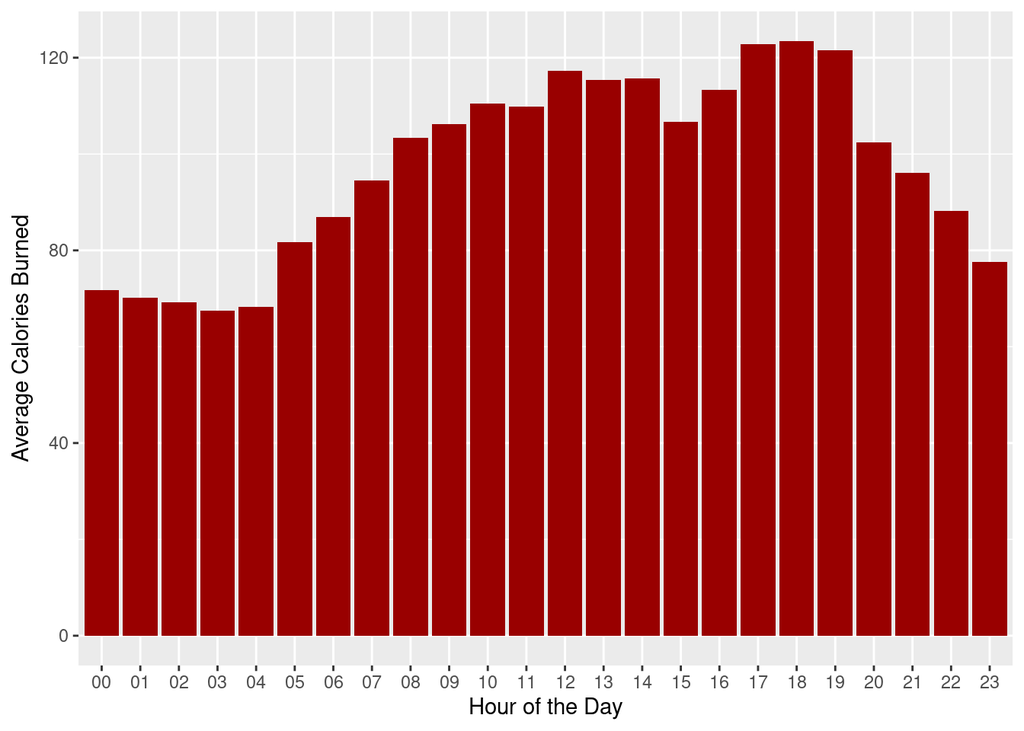

```r
#Calls the "visualHourlyCaloriesBurned" chart created in section 3
visualHourlyCaloriesBurned
```

We can start looking at the chart in phases to try and put some context to the calorie burned numbers displayed:

- **Phase 1:** Calorie burned numbers are at their lowest from the hours of 11 P.M. to 4 A.M., bottoming out at 3 A.M. This number makes sense, as we can expect that almost all of the users are asleep and burning minimal calories during those 5 hours.
- **Phase 2:** Calorie burned numbers start to rise until reaching a relative plateau for the day from the hours of 5 A.M to 9 A.M. This period most likely represents the hours that users start to wake up and burn more calories than their baseline sleep numbers. This waking up process happens over these 4 hours, indicated by the averages still being lower than the normal daylight hours, but rising over time, presumably as more and more people wake up.
- **Phase 3:** Averages start to plateau for the day at about 10 A.M., with a noticeable jump to new heights over the hours of 12 P.M, 1 P.M. and 2 P.M. After these three productive hours however, a noticeable drop to the average calories burned numbers occurs at 3 P.M. This could be casued by a variety of things, but further research would be needed to determine what exactly that would be. Either way, it looks like the post-lunch work wall is represented in this data.
- **Phase 4:** Things bounce back around 4 P.M., and rise to the highest three hours of calorie burning during the day over 5 P.M., 6 P.M. and 7 P.M. After the previously mentioned afternoon slowdown, user’s start to pick up the activity more and more, as normal business hours end and users start to move to go home, and potentially see to their exercise routines, or other activities that raise the calories burned number up above the daytime average.
- **Phase 5:** Finally, the calorie burned numbers start to slow down through the hours of 8 P.M., 9 P.M. and 10 P.M. The averages drop significatnly hour by hour, as user’s start to head off to sleep in chunks. The movement is similar to the run up observed at begining of the day as users wake up, just in the opposite direction.

Each of the phases listed in the above section could serve as a potential focus point for Bellabeat’s advertising efforts. For example, phase 2 could be looked at, and targeted advertisements could be made for groups that are waking up earlier than average. Further analysis could even be done by bringing in the sleeping data from the user data already obtained to further look into which wake up time is most popular, so as to give further insight on which group to target.

### **Analysis Question 2: Do fitness tracker users experience a drop in weight over time?**

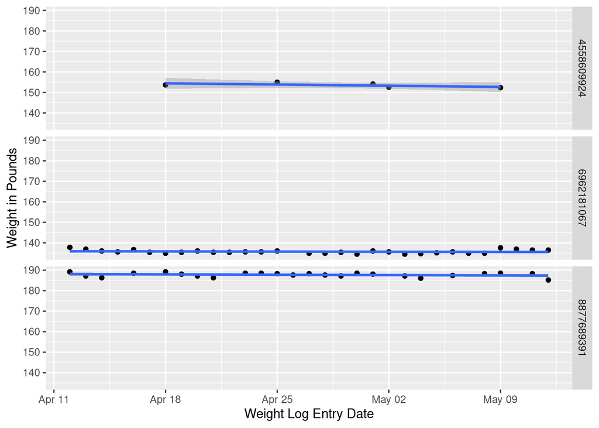

```r
#Calls the "visualWeightLogEntries" chart created in section 3
visualWeightLogEntries
```

To answer the question for this data established in section 2, the trend line on each graph can be looked at for a visual representation of how a user’s weight changed over time. If the trend line shows a significant downward trend, then the answer is yes, users do see a drop in weight when using the weight log function. However, looking at the visual, it is clear this is not the case for this time horizon. The trend line for each of the users that used the weight log function consistently is functionally flat. Therefore, it can be said that users who use the weight log feature do not see a noticeable drop in weight.

### **Analysis Question 3: How does a user’s resting heart rate vary, based on the amount of total time they spend in each of the activity levels?**

To interpret the graphs, the trend line on each graph can be looked at for a visual representation of how closely correlated the two variables are. A downward pointing trend line will indicate that the more time a user spends at the relative activity level, the lower their resting heart rates tend to be. The opposite is true with an upward facing trend line, the more minutes a user spends at the relative activity level, the higher their resting heart rate is. A flat line tends to indicate that there is no correlation between the two variables, and that a user’s time spent at the relative activity level does not have an effect on their resting heart rate.

The other aspect of the graph that appears with the trend line is the confidence interval for the trend line, or in other words, how accurately the trend line can be used to predict future data. This piece is shown by the darker gray outline around the trend line. The more narrow it is, the better the trend line is able to predict a variable given another variable, and vice versa. This aspect of the graph will be ignored for now, as we are not trying to predict variables in this analysis.

One important thing to note before the analysis is done is that the definition of each activity level is unknown. The source of the data failed to provide any metadata, and the data itself holds no indication. This is a limitation of the data, and before any conclusions can be definitively made for the basis of advertising, this will have to be solved.

#### **Minimum Heart Rate vs. Time Spent at Activity Level 0**

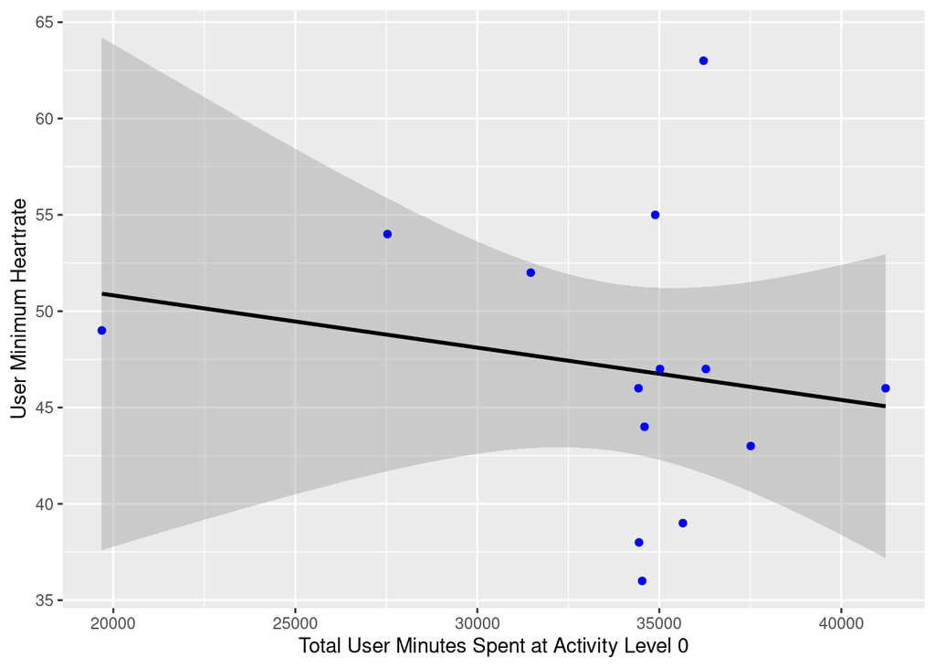

```r
#Calls the "visualMinHeartRate_vs_Level0" chart
visualminHeartRate_vs_Level0
```

This graph may be a good note of how much a user wears their fitness tracker. Just thinking about an average person’s day, the vast majority of their time will be spent at this activity level. Whether a user is sleeping, working, sitting down and eating, they will mostl likely fall in this category. Even if a user exercises regularly, the amount of time they will shave off from their time spent at activity level 0 will be minimally affected relative to the total. With this in mind, a user with a significantly more amount of minutes spent at level 0 probably wears their tracking devices more often.

This observation might not hold any weight to answer the question for this section, but could prove valuable in the iteration of another analysis, or the formulation of an entirely different question in the future.

#### **Minimum Heart Rate vs. Time Spent at Activity Level 1**

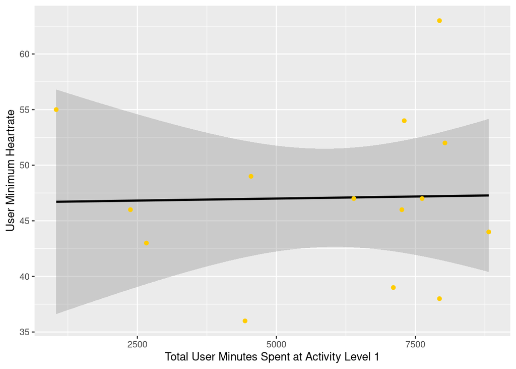

```r
#Calls the "visualMinHeartRate_vs_Level1" chart
visualminHeartRate_vs_Level1
```

#### **Minimum Heart Rate vs. Time Spent at Activity Level 2**

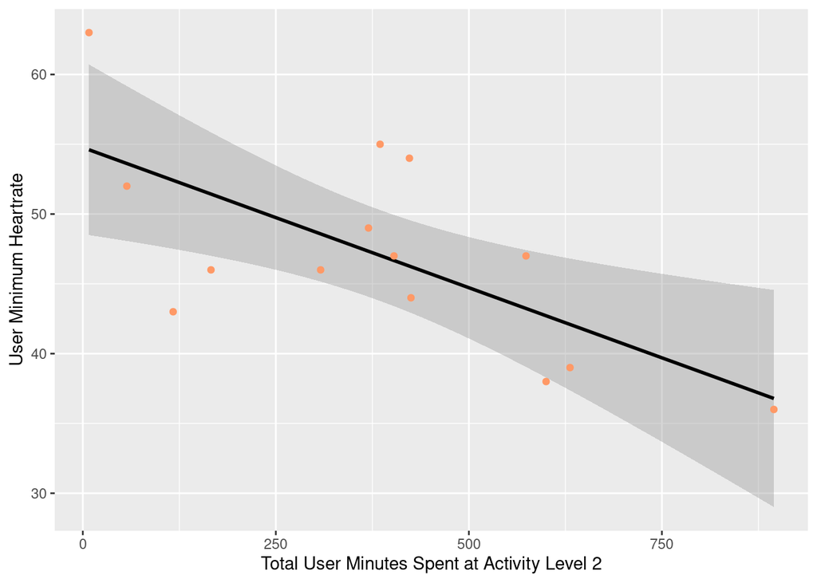

```r
#Calls the "visualMinHeartRate_vs_Level2" chart
visualminHeartRate_vs_Level2
```

Next up is looking at the relationship between time spent at activity level 2 vs. a user’s minimum heart rate. This is where the correlation between the activity time and minimum heart rate starts to show itself. Looking at the graph, The trend line shows a strong downward trend, indicating the more time a user spend at activity level 2, the lower their minimum heart rate is.

This is the activity level to focus attention on for advertising purposes, because of this relatively strong correlation. Bellabeat can use this to develop messages around their products ability to help measure how well a user is doing in their efforts to develop and maintain heart health, by lowering their heart rates.

#### **Minimum Heart Rate vs. Time Spent at Activity Level 3**

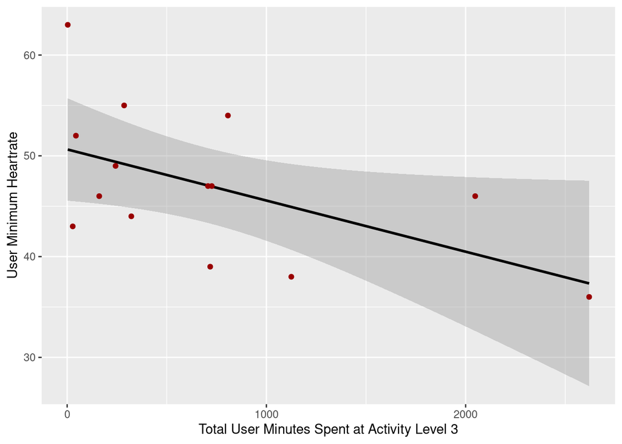

```r
#Calls the "visualMinHeartRate_vs_Level3" chart
visualminHeartRate_vs_Level3
```

## **Section 6: Conclusions and Wrap-Up**

Of the three questions that were originally sought to be answered, only two of them held any potential for being used as the basis for the formulation of advertising strategy. See the conclusions drawn from each of the questions, and how they could then be used to influence Bellabeat’s advertising, below:

### **Analysis Question 1: When in the day users typically burn their calories?**

This section of the analysis took the calories burned per hour, presumably gathered from the equivalent of either of the Bellabeat wearables, per day, per user, and then aggregated the data and found the average number of calories burned per hour per day. The hours of the day were then grouped into five groups based on the trends of the average calorie burned numbers and further analyzed in order to think of reasons behind why a certain group of hours displayed the trends they did.

The conclusion here is that any of those five groups represent an intriguing line of behavior that can stand as the basis of either future analysis to fine tune the conclusions drawn from each group, or to serve as the basis for advertising efforts now. For example, phase 5 shows the average number of calories burned later in the day as users are starting to fall asleep. Bellabeat could create an advertisement highlighting the fact that Bellabeat products are there no matter the users bed time, and monitors calorie-burned statistics, even while the user is resting. These statistics are then given to the user to alloww them to know where they are in their calorie expenditures, and subsequently plan calorie intake numbers to meet their weight and fitness goals.

### **Analysis Question 2: Do fitness tracker users experience a drop in weight over time?**

This section of the analysis monitored the weight of users who utilized the weight log functionality of their fitness trackers, presumably the equivalent of the Bellabeat app, in order to determine whether users who used this feature noticed a drop in their weight.

No definitive conclusions were able to be drawn from this phase of the analysis. The trend lines generated from the time-series analysis of the weight log data suggested that users did not see any change in weight, up or down, for those that used the weight log feature. Therefore, there wasn’t really a string to follow for the sake of coming up with advertising strategy.

### **Analysis Question 3: How does a user’s resting heart rate vary, based on the amount of total time they spend in each of the activity levels?**

Finally, this section looked to analyze the correlations between a user’s minimum heart rate, presumably gathered from the equivalent of either of the Bellabeat weratables, and the amount of time a user spent in each of the activity levels depicted in the data (levels 0 -3). 4 separate scatterplots were made with the user’s minimum heart rate data on the y axis, and each of the four activity levels on the x-axis on separate graphs.

## **Author’s Note**

If you’ve made it this far, thank you so much for reading till the end! I realize this project is a long one, and there is alot of content to digest and get through to get here. So thank you again for spending your valuable time reading through all of this and giving me the time of day.

If you were like me, there were points throughout the process of thinking through each of the analysis questions where further questions and analysis paths presented themselves. For example, with the first analysis question, I thought of cross referencing the drawdown and speed up of the average-calorie burned numbers at the end and begining of the day with user sleep data that also came with the baseline data set. However, in order to prevent a severe case of scope creep and allow myself to actually put a bow on this project, I opted to keep the analysis to the way it is now. Hopefully by reading through this, I was able to inspire you to look into those further questions on your own. Or, like me, those questions exist, but now you are ready to move on to the next thing before spending more time in the world of Bellabeat. I may return to build a V2 of this project, but for now, I am satisfied with the work I have done here.

If there are any questions I can answer at the end of the day, feel free to reach out, I would love the opportunity to talk to someone else about work that I did and am passionate about. But if not, know either way that I am grateful for your attention here.

Hopefully we will get the chance to talk soon, Blake